# IODS course project

Jouni Hirvonen

# About the project

“tunnelmat odottavat”

“kun oppisi R alkeet”

“Töissä kuulin”

https://github.com/jhirx/IODS-project

https://jhirx.github.io/IODS-project/

[Projekti sivu](https://jhirx.github.io/IODS-project/)

My try to make same Markdown document

## Reading data

Code for data creation is available at:  
https://github.com/jhirx/IODS-project/blob/master/data/create_learning2014.R

Let’s read the data in and make sure that gender is converted to factor

```r
setwd("~/IODS-project")
library(dplyr)
#learning2014 <-read.csv("~/IODS-project/data/learning2014.csv", sep="/t", header=TRUE)
#learning2014 <- read.csv("d:/yliopisto/IODS-project/data/learning2014.csv") %>%
learning2014 <- read.csv("~/IODS-project/data/learning2014.csv") %>%
 mutate_at(vars(gender), factor)
```

how data structure looks like

```r
str(learning2014)
```

```
## 'data.frame':    166 obs. of  8 variables:
##  $ X       : int  1 2 3 4 5 6 7 8 9 10 ...
##  $ gender  : Factor w/ 2 levels "F","M": 1 2 1 2 2 1 2 1 2 1 ...
##  $ age     : int  53 55 49 53 49 38 50 37 37 42 ...
##  $ attitude: num  3.7 3.1 2.5 3.5 3.7 3.8 3.5 2.9 3.8 2.1 ...
##  $ deep    : num  3.58 2.92 3.5 3.5 3.67 ...
##  $ stra    : num  3.38 2.75 3.62 3.12 3.62 ...
##  $ surf    : num  2.58 3.17 2.25 2.25 2.83 ...
##  $ points  : int  25 12 24 10 22 21 21 31 24 26 ...
```

## Exploring data

Here some figures to see how the data looks

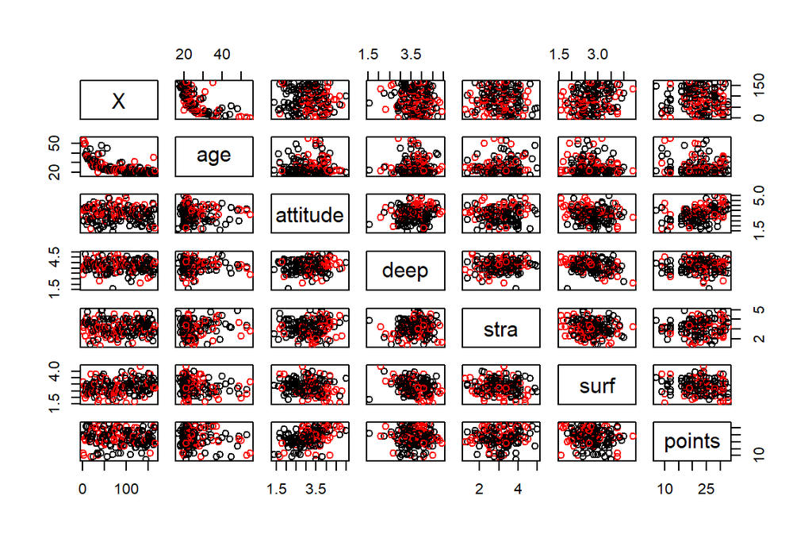

```r
pairs(learning2014[!names(learning2014) %in% c("gender")],col=learning2014$gender)
```

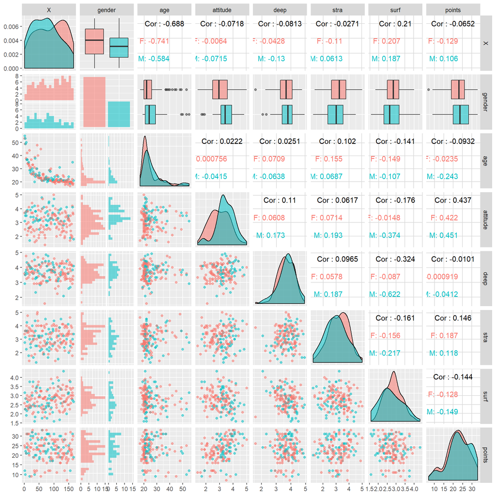

```r
library(GGally)
library(ggplot2)
# create a more advanced plot matrix with ggpairs()
ggpairs(learning2014,
        mapping = aes(col = gender, alpha = 0.3),
        lower = list(combo = wrap("facethist", bins = 20))
)
```

## Linear regression

The highest correlation is between *attitude* and *points*, **Cor:** 0.4365245. Let’s take a closer look.

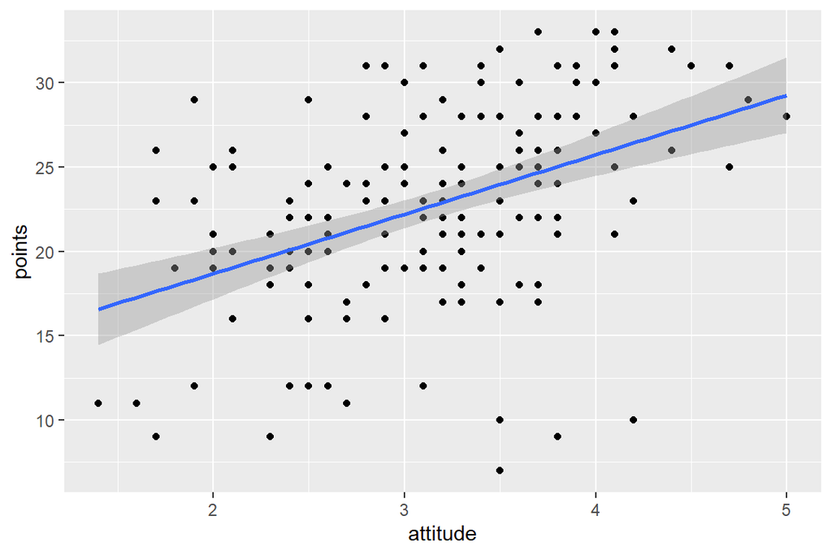

```r
qplot(attitude, points, data = learning2014) + geom_smooth(method = "lm")
```

Let’s fit a linear model to the data. Points are explained by attitude. The equation for the model is
$$Y_i = \alpha + \beta_1 X_i + \epsilon_i$$
where Y represent points, X is attitude, $\alpha$ is constant, $\beta_1$ is regression coefficient for attitude, and $\epsilon$ is a random term.

Estimation of the model yields the following results:

```r
my_model <- lm(points ~ attitude, data = learning2014)
results <- summary(my_model)
knitr::kable(results$coefficients, digits=3, caption="Regression coefficients")
```

Regression coefficients

|  | Estimate | Std. Error | t value | Pr(>\|t\|) |
| --- | --- | --- | --- | --- |
| (Intercept) | 11.637 | 1.830 | 6.358 | 0 |
| attitude | 3.525 | 0.567 | 6.214 | 0 |

Intercept as well as attitude are statistically significant predictors. Coefficient of determination $R^2$ = 0.1905537 that is not particularly high. Probably some more predictors could be added to the model.

# Logistic regression

Code for data creation is available at:  
https://github.com/jhirx/IODS-project/blob/master/data/chapter3.R

reading data in

```r
alc <- read.table("~/IODS-project/data/alc_table.csv", sep=",", header=TRUE)
library(dplyr); library(ggplot2)
```

My data (alcohol high use to explaning internet , romatic and sex = Gender )

```r
#my hypothese  (alcohol high use to explaning internet , romatic and sex = Gender )


m <- glm(high_use ~ internet + romantic + sex, data = alc, family = "binomial")

# print out a summary of the model where only sex have some signif
summary(m)
```

```
##
## Call:
## glm(formula = high_use ~ internet + romantic + sex, family = "binomial",
##     data = alc)
##
## Deviance Residuals:
##     Min       1Q   Median       3Q      Max
## -1.0190  -0.9674  -0.6727   1.3446   1.8019
##
## Coefficients:
##             Estimate Std. Error z value Pr(>|z|)
## (Intercept)  -1.4038     0.3316  -4.234  2.3e-05 ***
## internetyes   0.1647     0.3307   0.498 0.618393
## romanticyes  -0.1317     0.2499  -0.527 0.598181
## sexM          0.8544     0.2314   3.692 0.000223 ***
## ---
## Signif. codes:  0 '***' 0.001 '**' 0.01 '*' 0.05 '.' 0.1 ' ' 1
##
## (Dispersion parameter for binomial family taken to be 1)
##
##     Null deviance: 465.68  on 381  degrees of freedom
## Residual deviance: 450.45  on 378  degrees of freedom
## AIC: 458.45
##
## Number of Fisher Scoring iterations: 4
```

```r
# print out the coefficients of the model
coef(m)
```

```
## (Intercept) internetyes romanticyes        sexM
##  -1.4038271   0.1647092  -0.1316961   0.8543633
```

```r
# compute odds ratios (OR)
OR <- coef(m) %>% exp

# compute confidence intervals (CI)
CI <- confint(m) %>% exp
# print out the odds ratios with their confidence intervals , where same result only SEX influense alcohol use
cbind(OR, CI)
```

```
##                    OR     2.5 %    97.5 %
## (Intercept) 0.2456550 0.1241702 0.4588836
## internetyes 1.1790503 0.6278408 2.3136772
## romanticyes 0.8766073 0.5330916 1.4231966
## sexM        2.3498778 1.4991438 3.7195784
```

setting and calculatining probability and prediction (internet, romantic, sex, high_use, probability, prediction)

```r
# predict() the probability of high_use
probabilities <- predict(m, type = "response")

# add the predicted probabilities to 'alc'
alc <- mutate(alc, probability = probabilities)

# use the probabilities to make a prediction of high_use
alc <- mutate(alc, prediction = probability > 0.5)

# see the last ten original classes, predicted probabilities, and class predictions
#and we see probability and prediction is LOW
select(alc, internet, romantic, sex, high_use, probability, prediction) %>% tail(10)
```

```
##     internet romantic sex high_use probability prediction
## 373       no       no   M    FALSE   0.3659888      FALSE
## 374       no       no   M     TRUE   0.3659888      FALSE
## 375       no       no   F    FALSE   0.1972095      FALSE
## 376      yes      yes   F    FALSE   0.2024884      FALSE
## 377      yes       no   F    FALSE   0.2245896      FALSE
## 378      yes       no   F    FALSE   0.2245896      FALSE
## 379       no       no   F    FALSE   0.1972095      FALSE
## 380       no       no   F    FALSE   0.1972095      FALSE
## 381      yes       no   M     TRUE   0.4049807      FALSE
## 382      yes       no   M     TRUE   0.4049807      FALSE
```

```r
# tabulate the target variable versus the predictions
table(high_use = alc$high_use, prediction = alc$prediction)
```

```
##         prediction
## high_use FALSE
##    FALSE   268
##    TRUE    114
```

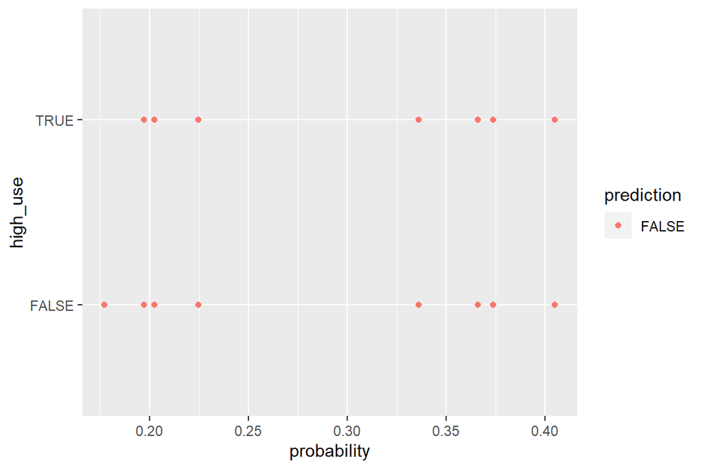

```r
# initialize a plot of 'high_use' versus 'probability' in 'alc'
g <- ggplot(alc, aes(x = probability, y = high_use, col = prediction))

# define the geom as points and draw the plot , tells something??
g + geom_point()
```

```r
#qplot(internet, romantic, high_use = alc) + geom_smooth(method = "lm")
# tabulate the target variable versus the predictions True und 0.5 so no prediction
table(high_use = alc$high_use, prediction = alc$prediction) %>% prop.table %>% addmargins
```

```
##         prediction
## high_use     FALSE       Sum
##    FALSE 0.7015707 0.7015707
##    TRUE  0.2984293 0.2984293
##    Sum   1.0000000 1.0000000
```

```r
#these my chosen variables have not relationships with alcohol consumption

# define a loss function (mean prediction error)
loss_func <- function(class, prob) {
  n_wrong <- abs(class - prob) > 0.5
  mean(n_wrong)
}

# call loss_func to compute the average number of wrong predictions in the (training) data
# 0,29... tells prediction is right
loss_func(class = alc$high_use, prob = 0)
```

```
## [1] 0.2984293
```

Cross-validation is a method of testing a predictive model on unseen data. In cross-validation, the value of a penalty (loss) function (mean prediction error) is computed on data not used for finding the model. Low value = good.

Cross-validation gives a good estimate of the actual predictive power of the model. It can also be used to compare different models or classification methods.

```r
# define a loss function (average prediction error)
loss_funca <- function(class, prob) {
  n_wrong <- abs(class - prob) > 0.5
  mean(n_wrong)
}

# compute the average number of wrong predictions in the (training) data, and perdiction
loss_funca(class = alc$high_use, prob = alc$probability)
```

```
## [1] 0.2984293
```

```r
# K-fold cross-validation
library(boot)
cv <- cv.glm(data = alc, cost = loss_func, glmfit = m, K = 10)

# average number of wrong predictions in the cross validation
cv$delta[1]
```

```
## [1] 0.2984293
```